# Homework 12 - Support Vector Machines

Sophie Shan

04/21/2024

# Credit card dataset

We will be working in this homework with a popular machine learning dataset about credit card fraud. Go to the following link and download the CSV:

https://www.openml.org/d/1597

The data description is

> The datasets contains transactions made by credit cards in September 2013 by european cardholders. This dataset present transactions that occurred in two days, where we have 492 frauds out of 284,807 transactions. The dataset is highly unbalanced, the positive class (frauds) account for 0.172% of all transactions.

Now we begin by reading into R:

```r
############################
#install necessary libraries
############################
#install.packages("farff")
#install.packages("readr")
#install.packages("tidyverse")
#install.packages("dplyr")
#install.packages("caret")
#install.packages("RANN")

library("farff")
library("readr")
library("tidyverse")
library("dplyr")
library("caret")
library("RANN")
```

```r
############################
#set working directory
############################
setwd("/Users/sophieshan/Desktop/OneDrive - University of North Carolina at Chapel Hill/UNC/Spring 2024/BIOS 735/Homework Assignments/HW12/")
```

```r
z <- readARFF("phpKo8OWT.arff")
```

```
## Parse with reader=readr : phpKo8OWT.arff
```

```
## header: 0.011000; preproc: 1.220000; data: 2.374000; postproc: 0.011000; total: 3.616000
```

```r
dim(z)
```

```
## [1] 284807     31
```

```r
table(z$Class)
```

```
##
##      0      1
## 284315    492
```

```r
y <- gsub("\\'","",z$Class)
x <- as.data.frame(z[,-31])
```

We will deal with the class imbalance for this homework just by downsampling the non-fraud cases. As we saw in the random forest homework there are other approaches including custom cost functions.

```r
set.seed(1)
idx <- c(sample(which(y == "0"), sum(y == "1")), which(y == "1"))
y <- y[idx]
x <- as.data.frame(scale(x[idx,]))
table(y)
```

```
## y
##   0   1
## 492 492
```

The homework assignment is to run linear and radial basis function SVM on the dataset, and report the Kappa for both models. For RBF, you should plot the Kappa over the different values for the cost function (`metric="Kappa"`).

```r
############################
#linear kernel SVM
############################
tg <- data.frame(C=50)
fit <- train(x, y, method="svmLinear", tuneGrid=tg)
fit$results
```

```
##    C  Accuracy     Kappa  AccuracySD    KappaSD
## 1 50 0.9322436 0.8643755 0.009918255 0.01979157
```

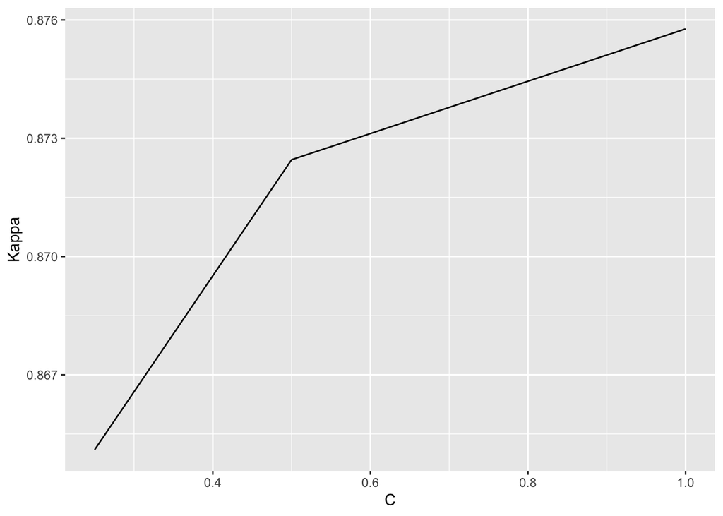

```r
############################
#radial basis function SVM
############################
rfit <- train(x, y, method = "svmRadial")
rfit$results %>%
  ggplot(aes(x=C,
             y=Kappa)) +
  geom_line()
```

Now, suppose we want to examine plots of the decision boundary in the feature space. We can only look at two features at a time in a scatter plot. What are the two most important variables for the SVMs (they are the same for both SVMs)?

```r
############################
#two most important variables
############################
varImp(fit) #linear SVMs: V14, V12
```

```
## ROC curve variable importance
##
##   only 20 most important variables shown (out of 30)
##
##     Importance
## V14     100.00
## V12      97.91
## V4       97.54
## V11      91.48
## V10      91.13
## V3       90.10
## V2       78.05
## V9       75.67
## V16      75.18
## V7       73.95
## V17      67.53
## V1       64.19
## V6       56.81
## V21      56.36
## V18      53.25
## V5       43.01
## V27      41.66
## V8       33.30
## V20      30.88
## V28      30.76
```

```r
varImp(rfit) #radial SVMs: V14, V12
```

```
## ROC curve variable importance
##
##   only 20 most important variables shown (out of 30)
##
##     Importance
## V14     100.00
## V12      97.91
## V4       97.54
## V11      91.48
## V10      91.13
## V3       90.10
## V2       78.05
## V9       75.67
## V16      75.18
## V7       73.95
## V17      67.53
## V1       64.19
## V6       56.81
## V21      56.36
## V18      53.25
## V5       43.01
## V27      41.66
## V8       33.30
## V20      30.88
## V28      30.76
```

```r
#Yes, the most important variables are the same for both SVMs.
```

Make a scatterplot for each method that includes: the data points in this two dimensional space, colored by the “0” and “1” prediction, and the decision boundary. In class, we simply used `expand.grid` to build the `newdata` that was fed to `predict`. Start with this approach, using a grid of 40 points from -4 to 4 for the two most important variables, but before you attempt to run `predict` (which would give an error), read further:

In this case, we have to worry about the other 30 - 2 = 28 variables. If we put in 0’s, this would not be typical observations, and we will get strange results.

Instead, you should put `NA` for the other variables, and use `preProcess` with KNN imputation (alone, don’t re-scale), to impute the other values. Then use this data to run `predict` and define the decision boundary. This is a simpler approach compared to the integration approach taken by `plot.gbm` to produce marginal plots that we saw when we looked at boosting, but it is sufficient to get a sense of the decision boundary in 2D for “typical” values of the other covariates.

```r
############################
#setup for plots
############################
#using a grid of 40 points from -4 to 4
s <- seq(from=-4,to=4,length=40)
grid <- expand.grid(V14=s,V12=s)

#put NA for the other variables
grid[ , setdiff(names(x), c("V14", "V12"))] <- NA
grid <- grid %>%
  relocate(V14, .before = V15) %>%
  relocate(V12, .before = V13)
x.pp <- preProcess(x, method=c("knnImpute"))
x.new <- predict(x.pp, grid)

#run predict
y.Linear <- predict(fit, newdata=x.new)
y.Radial <- predict(rfit, newdata=x.new)

#add to the x.new
x.new$y.Linear <- y.Linear
x.new$y.Radial <- y.Radial

#combined dataframe
dat <- data.frame(y,x$V14,x$V12)
colnames(dat) <- c("y", "V14", "V12")
```

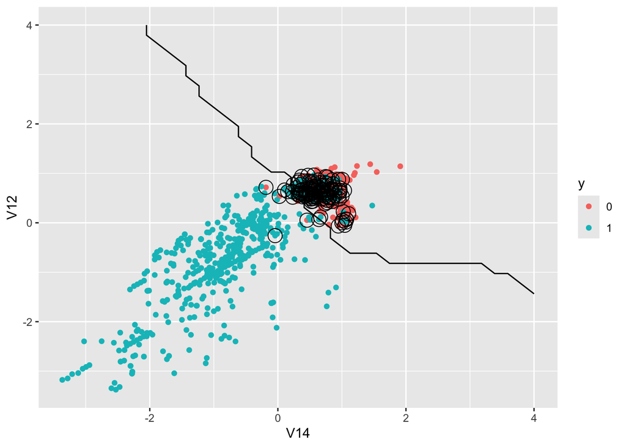

```r
############################
#linear kernel SVM
############################
sv <- as.data.frame(x[fit$finalModel@SVindex, c("V14", "V12")]) # the "support vectors"
x.new$yy.Linear <- 2*(as.numeric(x.new$y.Linear) - 1.5)


ggplot(dat, aes(V14, V12 ,col= y)) + geom_point() +
  geom_point(data=sv, col="black", size=5, shape=21) +
  geom_contour(data=x.new, aes(z=yy.Linear), breaks=0, col="black")
```

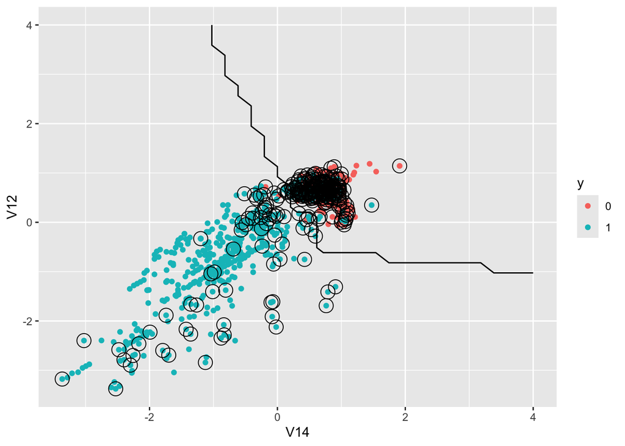

```r
############################
#radial basis function SVM
############################
rsv <- as.data.frame(x[rfit$finalModel@SVindex, c("V14", "V12")])
x.new$yy.Radial <- 2*(as.numeric(x.new$y.Radial) - 1.5)

ggplot(dat, aes(V14, V12 ,col= y)) + geom_point() +
  geom_point(data=rsv, col="black", size=5, shape=21) +
  geom_contour(data=x.new, aes(z = yy.Radial), breaks=0, col="black")
```

Do you see a big difference in the decision boundary for linear vs RBF SVM?

Doesn’t seem to be a big difference between the who decision boundaries.